# Fast BayesFPCA Vignette

Joe Sartini

2024-11-24

```r
source("FPCA_Processing/Libs.R")
source("FPCA_Processing/Extract_FE.R")
source("FPCA_Processing/Extract_EF.R")
source("FPCA_Processing/Extract_Scores.R")
```

## Read in the NHANES Accelerometry Data

For this brief example analysis, we leverage the objective physical activity data from wrist-worn accelerometry collected as part of NHANES 2011-2014. This dataset is made publicly available as part of [“Functional Data Analysis with R”](https://functionaldataanalysis.org) and can be downloaded from the accompanying website. We subsample the data to 20-minute averages as a pre-processing step and take a random subsample of 1000 individuals (still likely sufficient for an exploratory FPCA) for the sake of time.

```r
data_path = "http://www.ciprianstats.org/sites/default/files/nhanes/nhanes_fda_with_r.rds"
download.file(data_path, "nhanes.rds", mode = "wb")
accel_data = readRDS("nhanes.rds")
file.remove("nhanes.rds")

unAsIs <- function(X) {
  if("AsIs" %in% class(X)) {
    class(X) <- class(X)[-match("AsIs", class(X))]
  }
  X
}

chosen_idxs = sample(1:nrow(accel_data), 1000)
accel_mat = unAsIs(accel_data$MIMS)[chosen_idxs, ]
Day_Minutes = 1440
window_size = 20 # In minutes
accel_df = data.frame(accel_mat)
colnames(accel_df) = 1:Day_Minutes
accel_df$ID = accel_data$SEQN[chosen_idxs]
accel_df = accel_df %>%
  pivot_longer(-c(ID), names_to = "MoD", values_to = "MIMS") %>%
  mutate(Window = (as.numeric(MoD) - 1) %/% window_size) %>%
  group_by(ID, Window) %>%
  summarize(MIMS = mean(MIMS))
```

Now that we have the data, we perform quick visualizations to get an idea of the types of patterns present. We first randomly select 5 participant’s MIMS (monitor-independent movement summary) curves.

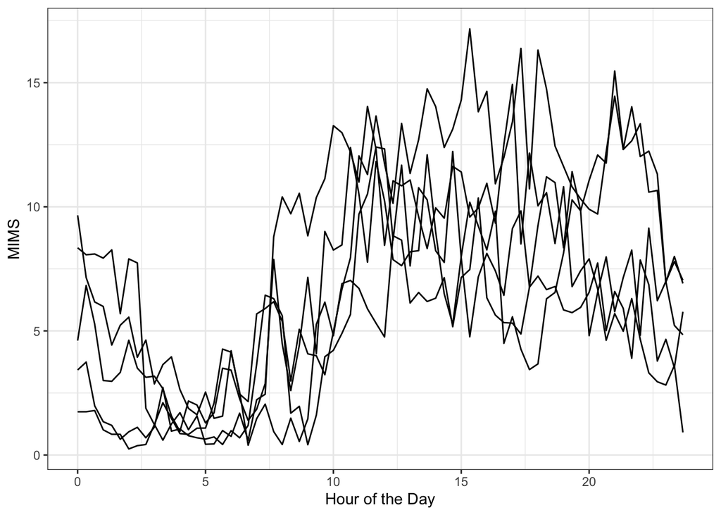

```r
chosen_ids = sample(unique(accel_df$ID), 5)
plot_df = accel_df %>%
  filter(ID %in% chosen_ids) %>%
  mutate(HoD = (Window * window_size)/60)

plot_df %>%
  ggplot(aes(x = HoD, y = MIMS, group = ID)) +
  geom_line() +
  theme_bw() +
  labs(x = "Hour of the Day", y = "MIMS")
```

We can alternatively visualize the entire population using a heatmap structure, where each row is a participant and darker colors correspond to higher activity levels (as in [“Functional Data Analysis with R”](https://functionaldataanalysis.org)).

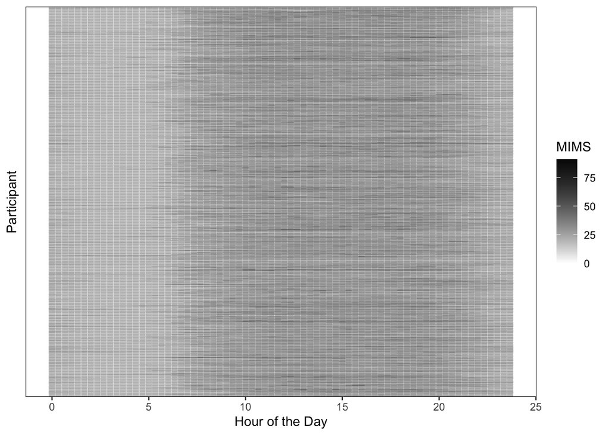

```r
accel_df %>%
  mutate(HoD = (Window * window_size)/60,
         ID = factor(ID)) %>%
  ggplot(aes(x = HoD, y = ID)) +
  geom_tile(aes(color = MIMS)) +
  theme_bw() +
  theme(axis.text.y = element_blank(), axis.ticks.y = element_blank(),
        panel.grid.major = element_blank(), panel.grid.minor = element_blank(),
        panel.background = element_blank()) +
  scale_color_gradient(low = "white", high = "black") +
  labs(x = "Hour of the Day", y = "Participant")
```

## Applying Fast BayesFPCA

```r
# Place data in wide, matrix format
Y_mat = accel_df %>%
  ungroup() %>%
  pivot_wider(names_from = Window, values_from = MIMS) %>%
  select(-c(ID)) %>% as.matrix()

# Define constants
spline_dim = 15
npc = 5
M = ncol(Y_mat)
domain = seq(0,1,length.out=M)

# Generate orthonormal spline basis and penalty
raw_splines = bSpline(domain, df = spline_dim, intercept = T)
raw_derivs = deriv(raw_splines, 2)

B = eigen(raw_splines %*% t(raw_splines))$vectors[,1:spline_dim]
basis_svd = svd(raw_splines)
pi_splines = basis_svd$v %*% diag(basis_svd$d^-1) %*% t(basis_svd$u)
transform = pi_splines %*% B
Bpp = raw_derivs %*% transform

p0 = (1/Day_Minutes) * t(B) %*% B
p1 = (1/Day_Minutes) * t(Bpp) %*% Bpp
Palpha = 0.1*p0 + 0.9*p1

# Collate list of arguments
data_list = list(N = nrow(Y_mat), M = M, Q = spline_dim, K = npc,
                 Y = Y_mat, B = B, P = Palpha)
```

Prior to fitting Fast BayesFPCA, we fit a standard FPCA using the FACE implementation, using the variance components and fixed effects to provide a reasonable sampling initiation.

```r
# Fit preliminary model using FACE for reasonable sampling initialization
stage_mod = fpca.face(Y_mat, knots = spline_dim, npc = npc, var = T)
scaling = diag(t(stage_mod$efunctions) %*% stage_mod$efunctions)[1:npc]
init_list = list(w_mu = coef(lm(stage_mod$mu ~ B - 1)),
                 lambda = rev(stage_mod$evalues[1:npc]*scaling),
                 sigma2 = stage_mod$sigma2)

fit_mod = stan(file = "STAN_Files/FPCA/FAST.stan",
               data = data_list,
               chains = 4,
               cores = 4,
               warmup = 2500,
               iter = 3000,
               init = list(init_list, init_list,
                           init_list, init_list),
               control = list(stepsize_jitter = 0.25))
```

With this model fit, we can now extract the estimated model components, fixed effects $\mu(t)$, eigenfunctions $\phi_k(t)$, scores $\xi_{ik}(t)$, and eigenvalues $\lambda_k$. We align the score and eigenfunction samples with the first sample to ensure consistent sign, given that the sign is non-identifiable by the FPCA definition.

```r
samples = extract(fit_mod)
vis_domain = (0:(Day_Minutes/window_size-1))*window_size/60

# Mu samples
mu_func = fast_FE(samples$w_mu, B, vis_domain)

# EF samples
preproc = fast_align(samples$Scores, samples$Psi, B)
EF_objs = fast_EF(samples$Psi, B, vis_domain,
                  preproc$Ord, preproc$Flip)

EF_estimate = EF_objs$Mean
EF_sample = EF_objs$Samples

Score_samples = fast_scores(samples$Scores, preproc$Ord, preproc$Flip)
EF_samples = Score_samples %>%
  group_by(EFNum, Sample) %>%
  summarize(EVal = var(Score)) %>%
  ungroup()
```

It is now straightforward to visualize the model components. We begin with the fixed effects mean $\mu(t)$, with the estimate, equal-tail 95% credible interval, and 3 posterior samples displayed.

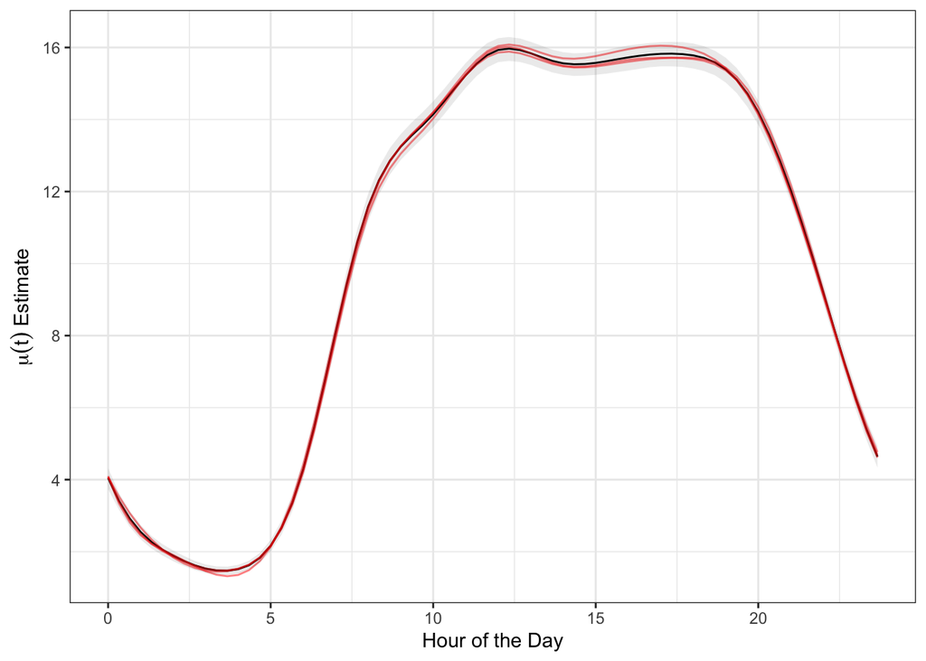

```r
chosen_samples = sample(mu_func$Sample, 3)

func_est = mu_func %>%
  group_by(Arg) %>%
  summarize(Estimate = mean(Mu))

func_band = mu_func %>%
  group_by(Arg) %>%
  summarize(Lower = quantile(Mu, probs = c(0.025)),
            Upper = quantile(Mu, probs = c(0.975)))

func_samples = mu_func %>%
  filter(Sample %in% chosen_samples)

func_est %>%
  ggplot(aes(x = Arg)) +
  geom_line(aes(y = Estimate)) +
  geom_line(data = func_samples, aes(y = Mu, group = Sample), color = "red", alpha = 0.5) +
  geom_ribbon(data = func_band, aes(ymin = Lower, ymax = Upper), alpha = 0.1) +
  theme_bw() +
  labs(x = "Hour of the Day", y = parse(text = "mu(t)~Estimate"))
```

We can similarly visualize the samples of eigenfunctions $\phi_k(t)$, again including the estimate, equal-tail 95% credible interval, and 3 posterior samples in red.

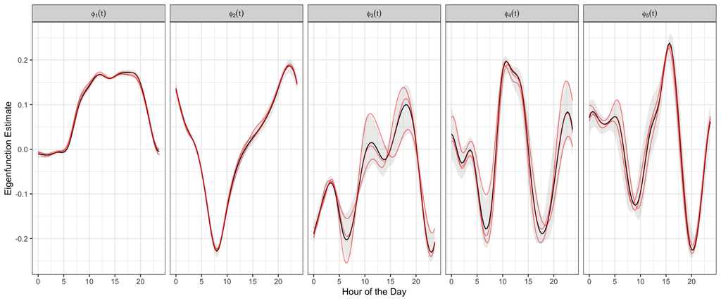

```r
func_est = EF_estimate %>%
  mutate(EFLab = paste0("phi[", substring(EFNum, 4), "](t)")) %>%
  select(-c(EFNum))

func_band = EF_sample %>%
  mutate(EFLab = paste0("phi[", substring(EFNum, 4), "](t)")) %>%
  select(-c(EFNum)) %>%
  group_by(EFLab, Arg) %>%
  summarize(Lower = quantile(EigFunc, probs = c(0.025)),
            Upper = quantile(EigFunc, probs = c(0.975)))

func_sample = EF_sample %>%
  mutate(EFLab = paste0("phi[", substring(EFNum, 4), "](t)")) %>%
  filter(Sample %in% chosen_samples)

func_est %>%
  ggplot(aes(x = Arg)) +
  geom_line(aes(y = Estimate)) +
  geom_line(data = func_sample, aes(y = EigFunc, group = Sample), color = "red", alpha = 0.5) +
  geom_ribbon(data = func_band, aes(ymin = Lower, ymax = Upper), alpha = 0.1) +
  facet_grid(.~EFLab, labeller = label_parsed) +
  theme_bw() +
  labs(x = "Hour of the Day", y = "Eigenfunction Estimate")
```

We can also evaluate the variability decomposition by plotting the estimated eigenvalues $\lambda_k$ sequentially with their equal-tail 95% credible intervals.

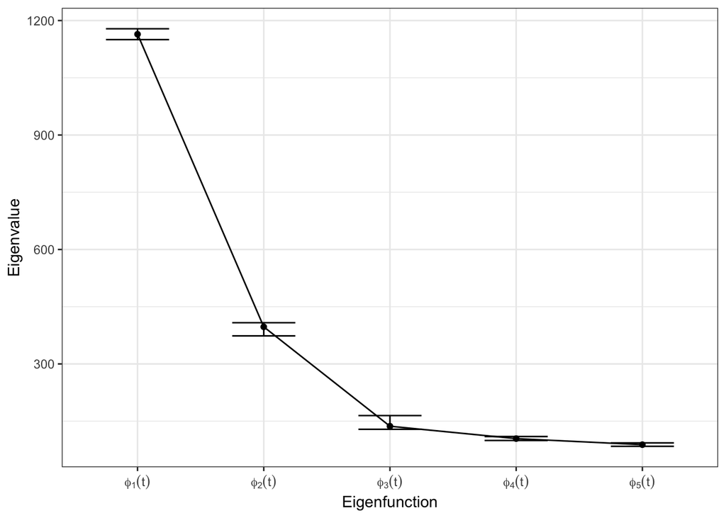

```r
labs = paste0("phi[", 1:npc, "](t)")
names(labs) = paste0("EF ", 1:npc)

EF_samples %>%
  group_by(EFNum) %>%
  summarize(Lower = quantile(EVal, probs = c(0.025)),
            Upper = quantile(EVal, probs = c(0.975)),
            Est = mean(EVal)) %>%
  ggplot(aes(x = EFNum, y = Est, group = "")) +
  geom_point() +
  geom_line() +
  geom_errorbar(aes(ymin = Lower, ymax = Upper), width = 0.5) +
  scale_x_discrete(labels = parse(text = labs)) +
  labs(x = "Eigenfunction", y = "Eigenvalue") +
  theme_bw()
```

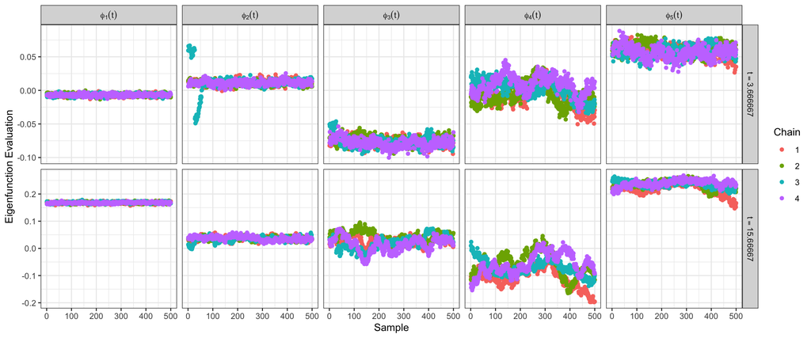

```r
chosen_args = vis_domain[c(12,48,84)]

anchor_EF = EF_sample %>%
  filter(Sample == 1) %>%
  pivot_wider(names_from = Arg, values_from = EigFunc) %>%
  select(-c(Sample, EFNum)) %>%
  as.matrix() %>% t()

psi_samples = extract(fit_mod, permuted = F, pars = "Psi")
score_samples = extract(fit_mod, permuted = F, pars = "Scores")
n_chains = dim(psi_samples)[2]
n_samples = dim(psi_samples)[1]

samples = map(1:n_chains, function(z){
  chain_psi = psi_samples[,z,]
  dim(chain_psi) = c(n_samples, spline_dim, npc)
  chain_scores = score_samples[,z,]
  n_scores = dim(chain_scores)[2]
  dim(chain_scores) = c(n_samples, n_scores/npc, npc)

  preproc = fast_align(chain_scores, chain_psi, B,
                       anchor = anchor_EF)
  EigFunc = fast_EF(chain_psi, B, vis_domain,
                    preproc$Ord, preproc$Flip)$Samples
  EigFunc$Chain = z

  return(EigFunc)
}) %>% list_rbind()

samples %>%
  filter(Arg %in% chosen_args) %>%
  mutate(Arg = factor(paste0("t==", Arg), levels = paste0("t==", chosen_args)),
         Chain = as.factor(Chain),
         EFLab = paste0("phi[", substring(EFNum, 4), "](t)")) %>%
  ggplot(aes(x = Sample, y = EigFunc)) +
  geom_point(aes(color = Chain)) +
  facet_grid(Arg~EFLab, scales = "free_y", labeller = label_parsed) +
  labs(x = "Sample", y = "Eigenfunction Evaluation") +
  theme_bw()
```